# SWMPr Workshop Part 1: Refresher on reading in data, and beginning to plot

Kim Cressman

2016-10-27

#### Step 1: Set the Working Directory

1. From the Rstudio menu bar, select ‘Session’ –> ‘Set Working Directory’ –> ‘Choose Directory’ (or use keyboard shortcut Ctrl + Shift + H)
2. You will see in the console a line that looks like this:

```r
setwd("C:/Users/kimberly.cressman/Desktop/NERRS SWMPr course 2016")
```

- notice the forward slashes!
  - you may have to change yours if you’re copying from windows explorer
- and the quotation marks!
- and the capitalization.
  - R is sensitive to capitalization.
3. Copy and paste that into your script window so you can just default to it every time you use this script
   - if Rstudio didn’t open with a blank script, click on the plus sign to create one.

#### Step 2: Read in a file (from your working directory)

Use the read.csv() command.

- The file name needs to be inside quotation marks (double “” or single ’’)
- Make sure the capitalization is correct
- Remember to include the file extension (.csv)
- Make sure your file is a .csv (there are packages that will read in Excel files for you, but .csv is simplist)
  - To convert a .xlsx file to a .csv, go to File –> Save as –> CSV (Comma Delimited)

`read.csv("GNDPCWQ2015.csv")`

To run a line of code:

- from the console: Enter
- from a script - **you should use scripts**
  - Ctrl + Enter OR
  - Ctrl + R OR
  - Run button in upper right corner of script panel
  - You can highlight and run more than one line in a script with any of these methods

Notice how that read it straight into your console?

If you want to work with the data (which you do!), you have to assign a name to it.

`my_object <- read.csv("my_file.csv")`

**You can choose to name it whatever you want - but you should pick a name that makes sense!**

Trust us: your object name will help you follow along and will make it easier to remember if it makes sense.

```r
wqdat <- read.csv("gndpcwq2015.csv")
```

#### Step 3: See what your new object looks like

**Look at the head of the data** (the first 6 rows)

Use the head() function:

```r
head(wqdat)
```

```
##   StationCode isSWMP   DateTimeStamp Historical ProvisionalPlus F_Record
## 1  gndpcwq         P 01/01/2015 0:00          0               1
## 2  gndpcwq         P 01/01/2015 0:15          0               1
## 3  gndpcwq         P 01/01/2015 0:30          0               1
## 4  gndpcwq         P 01/01/2015 0:45          0               1
## 5  gndpcwq         P 01/01/2015 1:00          0               1
## 6  gndpcwq         P 01/01/2015 1:15          0               1
##   Temp F_Temp SpCond F_SpCond  Sal F_Sal DO_Pct F_DO_Pct DO_mgl F_DO_mgl
## 1 13.8   <0>   43.58     <0>  28.1  <0>   100.4     <0>     8.7     <0>
## 2 13.6   <0>   43.31     <0>  27.9  <0>   100.2     <0>     8.8     <0>
## 3 13.5   <0>   43.17     <0>  27.8  <0>    99.4     <0>     8.7     <0>
## 4 13.2   <0>   42.93     <0>  27.6  <0>    99.4     <0>     8.8     <0>
## 5 13.1   <0>   42.58     <0>  27.4  <0>    99.9     <0>     8.8     <0>
## 6 13.2   <0>   42.45     <0>  27.3  <0>    99.4     <0>     8.8     <0>
##   Depth F_Depth cDepth F_cDepth Level F_Level cLevel F_cLevel  pH F_pH
## 1  1.35    <0>    1.21     <3>     NA   <-1>      NA       NA 8.2 <0>
## 2  1.33    <0>    1.19     <3>     NA   <-1>      NA       NA 8.2 <0>
## 3  1.32    <0>    1.18     <3>     NA   <-1>      NA       NA 8.2 <0>
## 4  1.29    <0>    1.15     <3>     NA   <-1>      NA       NA 8.2 <0>
## 5  1.27    <0>    1.13     <3>     NA   <-1>      NA       NA 8.2 <0>
## 6  1.26    <0>    1.12     <3>     NA   <-1>      NA       NA 8.2 <0>
##   Turb F_Turb ChlFluor F_ChlFluor  X
## 1    5   <0>        NA      <-1>  NA
## 2    5   <0>        NA      <-1>  NA
## 3    5   <0>        NA      <-1>  NA
## 4    4   <0>        NA      <-1>  NA
## 5    4   <0>        NA      <-1>  NA
## 6    5   <0>        NA      <-1>  NA
```

Notice, you did **not** have to put *wqdat* inside quotation marks. It is an object recognized by R. (You will also see it in the environment in the top right panel of RStudio.)

You can look at more rows if you want to. Let’s look at the first 10 rows:

```r
head(wqdat, 10)
```

```
##    StationCode isSWMP   DateTimeStamp Historical ProvisionalPlus F_Record
## 1   gndpcwq         P 01/01/2015 0:00          0               1
## 2   gndpcwq         P 01/01/2015 0:15          0               1
## 3   gndpcwq         P 01/01/2015 0:30          0               1
## 4   gndpcwq         P 01/01/2015 0:45          0               1
## 5   gndpcwq         P 01/01/2015 1:00          0               1
## 6   gndpcwq         P 01/01/2015 1:15          0               1
## 7   gndpcwq         P 01/01/2015 1:30          0               1
## 8   gndpcwq         P 01/01/2015 1:45          0               1
## 9   gndpcwq         P 01/01/2015 2:00          0               1
## 10  gndpcwq         P 01/01/2015 2:15          0               1
##    Temp F_Temp SpCond F_SpCond  Sal F_Sal DO_Pct F_DO_Pct DO_mgl F_DO_mgl
## 1  13.8   <0>   43.58     <0>  28.1  <0>   100.4     <0>     8.7     <0>
## 2  13.6   <0>   43.31     <0>  27.9  <0>   100.2     <0>     8.8     <0>
## 3  13.5   <0>   43.17     <0>  27.8  <0>    99.4     <0>     8.7     <0>
```

[output cut: 29 more lines]

**Look at the end of the data**

Again, the default is 6 rows, but you can tell it to show you more.

```r
tail(wqdat)
```

```
##       StationCode isSWMP    DateTimeStamp Historical ProvisionalPlus
## 35035  gndpcwq         P 12/31/2015 22:30          0               1
## 35036  gndpcwq         P 12/31/2015 22:45          0               1
## 35037  gndpcwq         P 12/31/2015 23:00          0               1
## 35038  gndpcwq         P 12/31/2015 23:15          0               1
## 35039  gndpcwq         P 12/31/2015 23:30          0               1
## 35040  gndpcwq         P 12/31/2015 23:45          0               1
##       F_Record Temp F_Temp SpCond F_SpCond  Sal F_Sal DO_Pct F_DO_Pct
## 35035    {CSM} 18.3   <0>   38.83     <0>  24.8  <0>    48.7     <0>
## 35036    {CSM} 18.4   <0>   39.39     <0>  25.2  <0>    47.6     <0>
## 35037    {CSM} 18.4   <0>   39.68     <0>  25.4  <0>    46.4     <0>
## 35038    {CSM} 18.4   <0>   39.81     <0>  25.5  <0>    45.5     <0>
## 35039    {CSM} 18.4   <0>   39.95     <0>  25.6  <0>    45.0     <0>
## 35040    {CSM} 18.4   <0>   40.09     <0>  25.7  <0>    44.4     <0>
##       DO_mgl F_DO_mgl Depth F_Depth cDepth F_cDepth Level F_Level cLevel
## 35035    4.0     <0>   1.45    <0>    1.36     <3>     NA   <-1>      NA
## 35036    3.9     <0>   1.45    <0>    1.35     <3>     NA   <-1>      NA
## 35037    3.7     <0>   1.46    <0>    1.37     <3>     NA   <-1>      NA
## 35038    3.7     <0>   1.44    <0>    1.35     <3>     NA   <-1>      NA
## 35039    3.6     <0>   1.44    <0>    1.35     <3>     NA   <-1>      NA
## 35040    3.6     <0>   1.44    <0>    1.35     <3>     NA   <-1>      NA
##       F_cLevel  pH F_pH Turb F_Turb ChlFluor F_ChlFluor  X
## 35035       NA 7.7 <0>     5   <0>        NA      <-1>  NA
## 35036       NA 7.7 <0>     5   <0>        NA      <-1>  NA
## 35037       NA 7.7 <0>     6   <0>        NA      <-1>  NA
## 35038       NA 7.7 <0>     6   <0>        NA      <-1>  NA
## 35039       NA 7.7 <0>     6   <0>        NA      <-1>  NA
## 35040       NA 7.7 <0>     6   <0>        NA      <-1>  NA
```

**Look at summary statistics of the data**

This shows you a lot of useful information: min and max, quartiles, median and average, and the number of NAs.

**Note:** NA is code for missing data.

*Hint:* by looking at this output, you can see if there are major problems in your data.

```r
summary(wqdat)
```

```
##      StationCode    isSWMP            DateTimeStamp     Historical
##  gndpcwq   :35040   P:35040   01/01/2015 0:00:    1   Min.   :0
##                               01/01/2015 0:15:    1   1st Qu.:0
##                               01/01/2015 0:30:    1   Median :0
##                               01/01/2015 0:45:    1   Mean   :0
##                               01/01/2015 1:00:    1   3rd Qu.:0
##                               01/01/2015 1:15:    1   Max.   :0
##                               (Other)        :35034
##  ProvisionalPlus  F_Record          Temp                     F_Temp
##  Min.   :1            :32928   Min.   :-991.5   <-2> [GMC]      :    5
##  1st Qu.:1       {CSM}: 2112   1st Qu.:  17.1   <-3> (CMC)      :    3
##  Median :1                     Median :  23.6   <-3> [GMC] (CND):    1
##  Mean   :1                     Mean   :  20.8   <-3> [STF]      :  724
##  3rd Qu.:1                     3rd Qu.:  28.8   <0>             :34292
##  Max.   :1                     Max.   :  33.8   <0> (CND)       :   15
##                                NA's   :5
##      SpCond                   F_SpCond          Sal
##  Min.   :-676.00   <0>            :30476   Min.   :-99.00
##  1st Qu.:  28.34   <1> [SPC] (CBF): 1827   1st Qu.: 17.20
##  Median :  38.76   <1> (CSM)      : 1283   Median : 24.60
##  Mean   :  43.64   <-3> [STF]     :  724   Mean   : 25.74
##  3rd Qu.:  43.67   <1> [SPC] (CSM):  509   3rd Qu.: 28.00
##  Max.   :8384.84   <-3> [SSM]     :  183   Max.   :999.90
##  NA's   :5         (Other)        :   38   NA's   :5
##              F_Sal           DO_Pct                   F_DO_Pct
##  <0>            :30476   Min.   :  4.20   <0>             :33298
##  <1> [SPC] (CBF): 1827   1st Qu.: 87.50   <-3> [STF]      :  724
##  <1> (CSM)      : 1283   Median : 95.90   <-3> [SPC] (CBF):  640
##  <-3> [STF]     :  724   Mean   : 94.73   <0> (CDA)       :  125
##  <1> [SPC] (CSM):  509   3rd Qu.:103.40   <-3> [SWM] (CBF):  120
##  <-3> [SSM]     :  183   Max.   :313.80   <-3> (CMD)      :   42
##  (Other)        :   38   NA's   :5        (Other)         :   91
##      DO_mgl                    F_DO_mgl         Depth
##  Min.   :  0.300   <0>             :33115   Min.   :0.000
##  1st Qu.:  6.200   <-3> [STF]      :  724   1st Qu.:1.270
##  Median :  7.200   <-3> [SPC] (CBF):  640   Median :1.390
##  Mean   :  7.825   <-3> [SCF]      :  183   Mean   :1.397
##  3rd Qu.:  8.500   <0> (CDA)       :  125   3rd Qu.:1.520
##  Max.   :159.100   <-3> [SWM] (CBF):  120   Max.   :2.140
##  NA's   :5         (Other)         :  133   NA's   :5
```

[output cut: 17 more lines]

```
##  <0>             :32735   Min.   :   -5.0   <0>             :26977
##  <1> [SPC] (CBF) :  846   1st Qu.:    8.0   <1> [GSM] (CWE) : 4552
##  <-3> [STF]      :  724   Median :   21.0   <-3> [SPC] (CBF):  772
##  <0> (CRE)       :  581   Mean   :  124.9   <-3> [STF]      :  724
##  <-3> [SPC] (CBF):  121   3rd Qu.:   58.0   <-3> (CBF)      :  720
##  <0> (CND)       :   15   Max.   :26790.0   <-3> (CMD)      :  573
##  (Other)         :   18   NA's   :5         (Other)         :  722
##  ChlFluor       F_ChlFluor       X
##  Mode:logical   <-1> :35040   Mode:logical
##  NA's:35040                   NA's:35040
##
##
##
##
##
```

**Look only at the column names**

This is especially helpful if you’ve been working on a script for a while but don’t remember exactly how the name of your variable is showing up (capitalization, underscores, etc. - we name things differently sometimes in different files!)

```r
names(wqdat)
```

```
##  [1] "StationCode"     "isSWMP"          "DateTimeStamp"
##  [4] "Historical"      "ProvisionalPlus" "F_Record"
##  [7] "Temp"            "F_Temp"          "SpCond"
## [10] "F_SpCond"        "Sal"             "F_Sal"
## [13] "DO_Pct"          "F_DO_Pct"        "DO_mgl"
## [16] "F_DO_mgl"        "Depth"           "F_Depth"
## [19] "cDepth"          "F_cDepth"        "Level"
## [22] "F_Level"         "cLevel"          "F_cLevel"
## [25] "pH"              "F_pH"            "Turb"
## [28] "F_Turb"          "ChlFluor"        "F_ChlFluor"
## [31] "X"
```

**Look at the structure of the dataset**

This shows you what *type* of variable each column is: date, numeric, character, logical (true/false), etc.

```r
str(wqdat)
```

```
## 'data.frame':    35040 obs. of  31 variables:
##  $ StationCode    : Factor w/ 1 level "gndpcwq   ": 1 1 1 1 1 1 1 1 1 1 ...
##  $ isSWMP         : Factor w/ 1 level "P": 1 1 1 1 1 1 1 1 1 1 ...
##  $ DateTimeStamp  : Factor w/ 35040 levels "01/01/2015 0:00",..: 1 2 3 4 5 6 7 8 49 50 ...
##  $ Historical     : int  0 0 0 0 0 0 0 0 0 0 ...
##  $ ProvisionalPlus: int  1 1 1 1 1 1 1 1 1 1 ...
##  $ F_Record       : Factor w/ 2 levels "","{CSM}": 1 1 1 1 1 1 1 1 1 1 ...
##  $ Temp           : num  13.8 13.6 13.5 13.2 13.1 13.2 13.1 13.1 13.1 13 ...
##  $ F_Temp         : Factor w/ 6 levels "<-2> [GMC]","<-3> (CMC)",..: 5 5 5 5 5 5 5 5 5 5 ...
##  $ SpCond         : num  43.6 43.3 43.2 42.9 42.6 ...
##  $ F_SpCond       : Factor w/ 11 levels "<-2> [GMC]","<-3> (CMC)",..: 7 7 7 7 7 7 7 7 7 7 ...
##  $ Sal            : num  28.1 27.9 27.8 27.6 27.4 27.3 27 26.9 26.9 26.6 ...
##  $ F_Sal          : Factor w/ 11 levels "<-2> [GMC]","<-3> (CMC)",..: 7 7 7 7 7 7 7 7 7 7 ...
##  $ DO_Pct         : num  100.4 100.2 99.4 99.4 99.9 ...
##  $ F_DO_Pct       : Factor w/ 13 levels "<-2> [GMC]","<-3> (CMC)",..: 8 8 8 8 8 8 8 8 8 8 ...
```

[output cut: 17 more lines]

#### Step 4: Make a plot

Let’s look at temperature over time. Basic plots are easy:

`plot(y ~ x, data = your data)`

In this specific case, it’s:

`plot(Temp ~ DateTimeStamp, data=wqdat)`

But this throws errors! Let’s look at just these two columns of data by using the $ selector:

```r
str(wqdat$Temp)
```

```
##  num [1:35040] 13.8 13.6 13.5 13.2 13.1 13.2 13.1 13.1 13.1 13 ...
```

```r
str(wqdat$DateTimeStamp)
```

```
##  Factor w/ 35040 levels "01/01/2015 0:00",..: 1 2 3 4 5 6 7 8 49 50 ...
```

**`DateTimeStamp`** is seen as a factor. We need it to be seen as a date.

What we’ll do is turn it into a **class** called `POSIXct`, which is a good one to work with date-times. (There’s also a class called `Date` if you’re ever working with a simpler dataset - date format is a bit easier to work with.)

**This is something SWMPr does automatically** as it reads in files, but we’re not there yet in this course. So we’ll do it by hand.

I’m going to make a new column, called `DateTime`. You could write over the original column if you want to. I’m hesitant to do that until I know I have something working.

We have to tell R what format the date/time in the current column is in, so that everything goes in the right place when it’s turned into `POSIXct`. Notice the capitalization! (`%m` = month; `%M` = minutes)

To make a new column, we’re doing the same thing we did when we created the data frame in the first place:

`Data_Frame$New_Column <- whatever we're doing to create the new column`

```r
wqdat$DateTime <- as.POSIXct(wqdat$DateTimeStamp, format="%m/%d/%Y %H:%M", tz="America/Regina")
```

Again, format is how you want your date to be read. `%m` is numerical month (01 = January), `%d` is numerical day (1-31), `%Y` is the numerical 4 digit year (ex. 2015), `%H` is hour, and `%M` is minute. This is how the SWMP data is formatted, so we’ll stick with it, but you could format months for example as `%b` (Jan, Feb, Mar, etc).

The timezone code matters - POSIXct will automatically adjust time stamps for Daylight Savings Time, and because we don’t adjust our monitoring equipment, we definitely don’t want R making that adjustment in the background.

We better check to make sure everything looks right before proceeding:

```r
head(wqdat)
```

```
##   StationCode isSWMP   DateTimeStamp Historical ProvisionalPlus F_Record
## 1  gndpcwq         P 01/01/2015 0:00          0               1
## 2  gndpcwq         P 01/01/2015 0:15          0               1
## 3  gndpcwq         P 01/01/2015 0:30          0               1
## 4  gndpcwq         P 01/01/2015 0:45          0               1
## 5  gndpcwq         P 01/01/2015 1:00          0               1
## 6  gndpcwq         P 01/01/2015 1:15          0               1
##   Temp F_Temp SpCond F_SpCond  Sal F_Sal DO_Pct F_DO_Pct DO_mgl F_DO_mgl
## 1 13.8   <0>   43.58     <0>  28.1  <0>   100.4     <0>     8.7     <0>
## 2 13.6   <0>   43.31     <0>  27.9  <0>   100.2     <0>     8.8     <0>
## 3 13.5   <0>   43.17     <0>  27.8  <0>    99.4     <0>     8.7     <0>
## 4 13.2   <0>   42.93     <0>  27.6  <0>    99.4     <0>     8.8     <0>
## 5 13.1   <0>   42.58     <0>  27.4  <0>    99.9     <0>     8.8     <0>
## 6 13.2   <0>   42.45     <0>  27.3  <0>    99.4     <0>     8.8     <0>
##   Depth F_Depth cDepth F_cDepth Level F_Level cLevel F_cLevel  pH F_pH
## 1  1.35    <0>    1.21     <3>     NA   <-1>      NA       NA 8.2 <0>
## 2  1.33    <0>    1.19     <3>     NA   <-1>      NA       NA 8.2 <0>
## 3  1.32    <0>    1.18     <3>     NA   <-1>      NA       NA 8.2 <0>
## 4  1.29    <0>    1.15     <3>     NA   <-1>      NA       NA 8.2 <0>
## 5  1.27    <0>    1.13     <3>     NA   <-1>      NA       NA 8.2 <0>
## 6  1.26    <0>    1.12     <3>     NA   <-1>      NA       NA 8.2 <0>
##   Turb F_Turb ChlFluor F_ChlFluor  X            DateTime
## 1    5   <0>        NA      <-1>  NA 2015-01-01 00:00:00
## 2    5   <0>        NA      <-1>  NA 2015-01-01 00:15:00
## 3    5   <0>        NA      <-1>  NA 2015-01-01 00:30:00
## 4    4   <0>        NA      <-1>  NA 2015-01-01 00:45:00
## 5    4   <0>        NA      <-1>  NA 2015-01-01 01:00:00
## 6    5   <0>        NA      <-1>  NA 2015-01-01 01:15:00
```

```r
str(wqdat)
```

```
## 'data.frame':    35040 obs. of  32 variables:
##  $ StationCode    : Factor w/ 1 level "gndpcwq   ": 1 1 1 1 1 1 1 1 1 1 ...
##  $ isSWMP         : Factor w/ 1 level "P": 1 1 1 1 1 1 1 1 1 1 ...
##  $ DateTimeStamp  : Factor w/ 35040 levels "01/01/2015 0:00",..: 1 2 3 4 5 6 7 8 49 50 ...
##  $ Historical     : int  0 0 0 0 0 0 0 0 0 0 ...
##  $ ProvisionalPlus: int  1 1 1 1 1 1 1 1 1 1 ...
##  $ F_Record       : Factor w/ 2 levels "","{CSM}": 1 1 1 1 1 1 1 1 1 1 ...
##  $ Temp           : num  13.8 13.6 13.5 13.2 13.1 13.2 13.1 13.1 13.1 13 ...
##  $ F_Temp         : Factor w/ 6 levels "<-2> [GMC]","<-3> (CMC)",..: 5 5 5 5 5 5 5 5 5 5 ...
##  $ SpCond         : num  43.6 43.3 43.2 42.9 42.6 ...
##  $ F_SpCond       : Factor w/ 11 levels "<-2> [GMC]","<-3> (CMC)",..: 7 7 7 7 7 7 7 7 7 7 ...
##  $ Sal            : num  28.1 27.9 27.8 27.6 27.4 27.3 27 26.9 26.9 26.6 ...
##  $ F_Sal          : Factor w/ 11 levels "<-2> [GMC]","<-3> (CMC)",..: 7 7 7 7 7 7 7 7 7 7 ...
##  $ DO_Pct         : num  100.4 100.2 99.4 99.4 99.9 ...
##  $ F_DO_Pct       : Factor w/ 13 levels "<-2> [GMC]","<-3> (CMC)",..: 8 8 8 8 8 8 8 8 8 8 ...
```

[output cut: 18 more lines]

Okay. Let’s try this plot again:

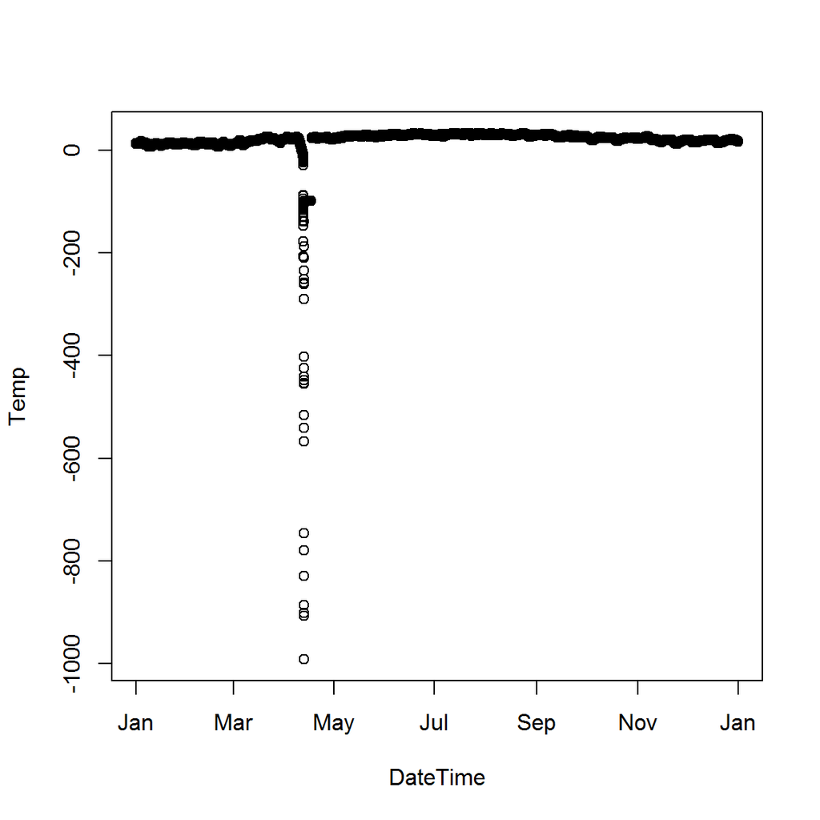

```r
plot(Temp ~ DateTime, data=wqdat)
```

Let’s change a few options - turn it into a line, and make that line red. Let’s also give it some titles.

To figure out other plot options, type this into your console:

`?plot`

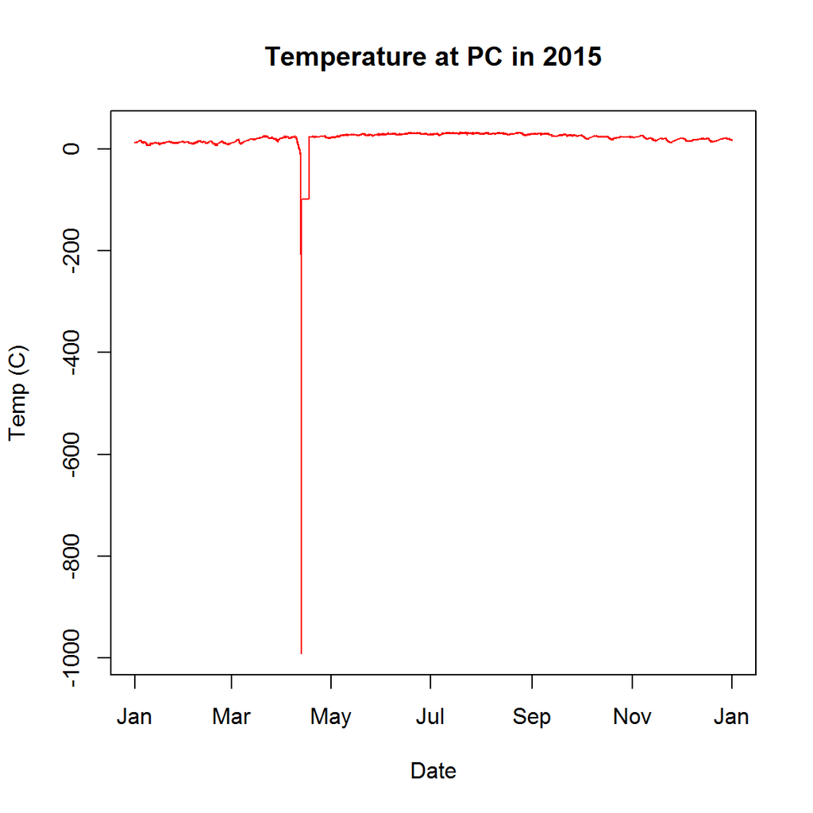

```r
plot(Temp ~ DateTime, data = wqdat,
     type = "l",
     col = "red",
     main = "Temperature at PC in 2015",
     xlab = "Date",
     ylab = "Temp (C)")
```

We can even change that y-axis to a more realistic scale:

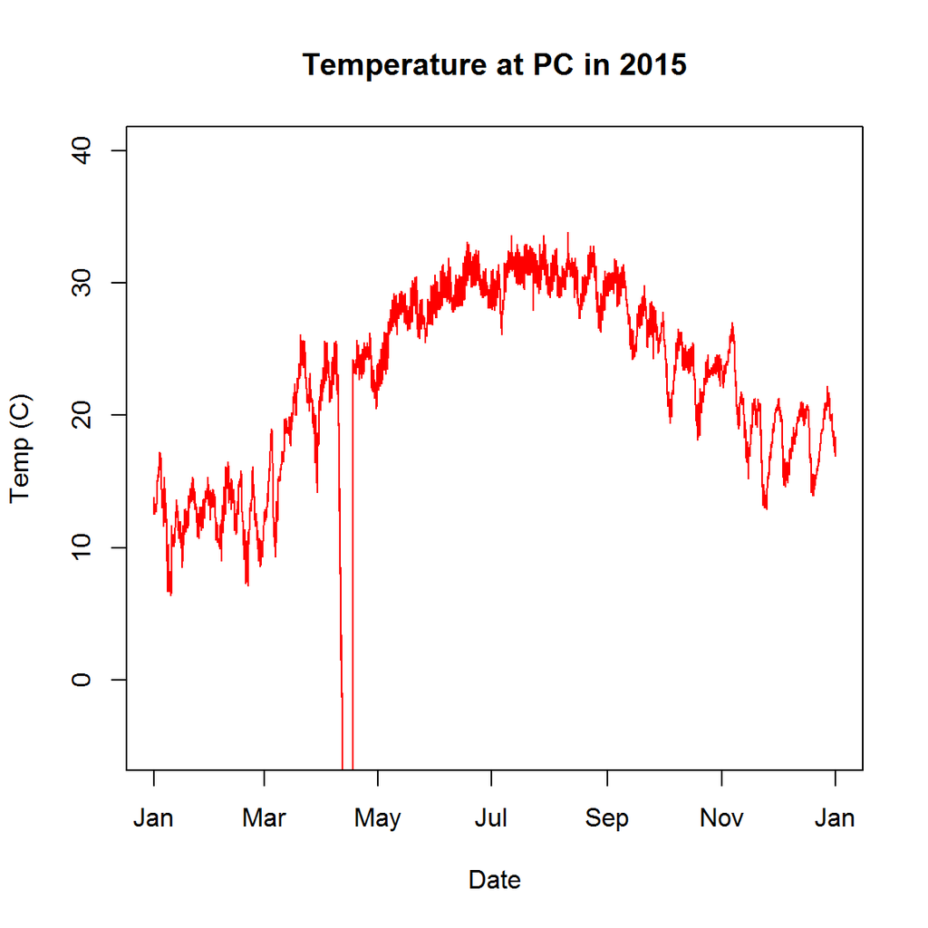

```r
plot(Temp ~ DateTime, data = wqdat,
     type = "l",
     col = "red",
     main = "Temperature at PC in 2015",
     xlab = "Date",
     ylab = "Temp (C)",
     ylim = c(-5, 40))
```

We can also add that special degree symbol to make it publication-ready (*fun fact*: Kim learned this from Kari as they were planning this workshop):

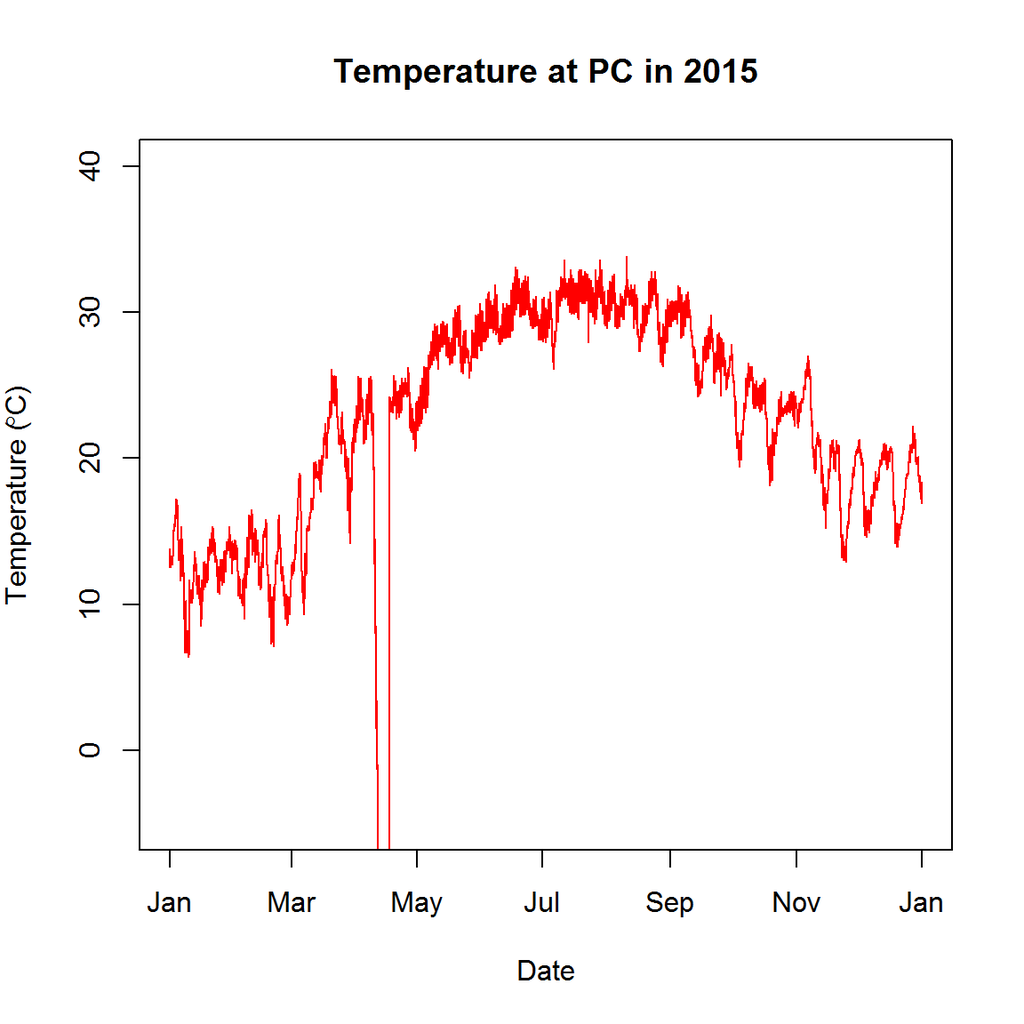

```r
plot(Temp ~ DateTime, data = wqdat,
     type = "l",
     col = "red",
     main = "Temperature at PC in 2015",
     xlab = "Date",
     ylab = expression(paste("Temperature (",degree,"C)")),
     ylim = c(-5, 40))
```

**So we’ve already got several needs, and we’re not even to the analysis stage yet:**

- We need an easy way to get rid of bad data.
- We need an easy way to turn date-time stamps into POSIXct.
- We need an easy way to read in a lot of SWMP data and do each of the above.

**Enter the SWMPr package**

- What is a package, generally, and why do I need them?
- What are some popular packages?
  - `ggplot2` for easy graphing
  - `dplyr` and `tidyr` for data wrangling
  - `wq` and `EnvStats` for statistics
  - `openair` for wind roses
  - `knitr` for generating nice documents from code and outputs
  - `grDevices` for more color and font options
- How do I get packages onto my computer?
  - `install.packages("SWMPr")` for just one
  - `install.packages(c("SWMPr", "tidyr", "ggplot2"))` for multiple
- How do I use a package?
  - load at the beginning of a session using either:
  - `library(SWMPr)` in your script
  - check `SWMPr` on the Packages tab in the bottom right panel of RStudio
  - notice that you *do* need quotation marks to install a package, but you *do not* use them to load a package.

**Next, we’ll use SWMPr to read in and QC some real data!**

.